# Tim’s homework 5 performed with R

##### 1. Obtain the data and read it into a data frame

After skimming the file, I have got two strategies to read the file into a data frame.

```r
df <- readLines("https://ftp.ncbi.nlm.nih.gov/geo/series/GSE2nnn/GSE2583/suppl/GSE2583_correctly_ordered_Klevecz_GEO_time_series_data.txt")

df[c(1:3,56:59)]
```

```
  [1] "!Series_title\tGenome_Wide_Oscillations_in_Yeast"
  [2] "!Series_geo_accession\tGSE2583"
  [3] "!Series_status\tPublic on Apr 29 2005"
  [4] "\t\t\t\t\t\t\t\t\t\t\t\t\t\t\t\t\t\t\t\t\t\t\t\t\t\t\t\t\t\t\t\t!series_matrix_table_begin"
  [5] "GSM48136\tGSM48137\tGSM48138\tGSM48139\tGSM48140\tGSM48131\tGSM48132\tGSM48133\tGSM48134\tGSM48135\tGSM48149\tGSM48150\tGSM48141\tGSM48151\tGSM48142\tGSM48143\tGSM48144\tGSM48145\tGSM48146\tGSM48147\tGSM48148\tGSM48160\tGSM48161\tGSM48162\tGSM48157\tGSM48158\tGSM48152\tGSM48159\tGSM48153\tGSM…
  [6] "5.8\t7.9\t5.8\t8.7\t10.7\t6.8\t3\t19.8\t1.1\t2.1\t0.6\t7\t4.8\t4.4\t6.7\t8.8\t8.6\t8.2\t10.2\t5.1\t7.5\t8\t6.8\t2.6\t4.3\t9.5\t9.5\t9.1\t6\t5.4\t8.6\t13.8\t10000_at"
  [7] "175.2\t218.2\t379.3\t448.9\t470.4\t375.6\t363\t443.7\t304.4\t289.3\t186.5\t260.6\t216\t211.2\t266.6\t335\t366\t377.9\t296.8\t405.9\t342\t295.4\t322.1\t232\t278.7\t261.8\t386.2\t430.3\t331.9\t453.4\t348.8\t228.3\t10001_at"
```

```r
t <- grep('matrix_table',df) # locate the position of the two sentences
read_start <- t[1] + 1 # reservation starts
read_end <- t[2] - 1 # reservation ends

df <- df[read_start:read_end] # keep the data part
df <- as.character(unlist(strsplit(df, "\t"))) # Breaking strings with "\t"
df <- matrix(df,nrow=33) # Employing all broken strings to form a matrix
df <- data.frame(t(df), stringsAsFactors = F) # Removing factor characteristic of all the strings

# Assigning row/column names to the data frame, and removing the corresponding content
rownames(df) <- df[,33]
colnames(df) <- df[1,]

df <- df[,-33]
df <- df[-1,]

# Transferring a string data frame to a numeric data frame
df.rownames <- row.names(df)
df <- data.frame(sapply(df, as.numeric))
rownames(df) <- df.rownames
rm(df.rownames)

# Checking the data frame
head(df[c(1:7)])
```

```
             GSM48136 GSM48137 GSM48138 GSM48139 GSM48140 GSM48131 GSM48132
  10000_at        5.8      7.9      5.8      8.7     10.7      6.8      3.0
  10001_at      175.2    218.2    379.3    448.9    470.4    375.6    363.0
  10002_i_at   1317.7   1388.5   1886.5   1967.7   1489.0   1321.5   1246.6
  10003_f_at   2920.1   3637.7   3729.1   3368.9   3175.5   2258.2   2703.8
  10004_at        6.0      5.6      5.6     10.3     12.0      7.3     10.9
  10005_at      110.1    106.3    128.7    141.4    128.0    134.3    140.2
```

##### 2. Filter the data

remove NAN values

```r
dim(df) # row number and column number checking
```

```
  [1] 9335   32
```

```r
df <- na.omit(df)

dim(df)
```

```
  [1] 9335   32
```

Comparing before and after NAN trimming, basically, there are no NAN values in the data frame

Calculate the variance as well as the coefficient of each row, and then plot the results.

R has its build-in function *var()* to calculate variance, and by applying this function, I build a function to get the coefficient of variance (CV).

```r
The_variance <- apply(df, 1, function(x) var(x))
The_coef <- apply(df, 1, function(x) sqrt(var(x))/mean(x))
```

The ploting results showing like figure 1.

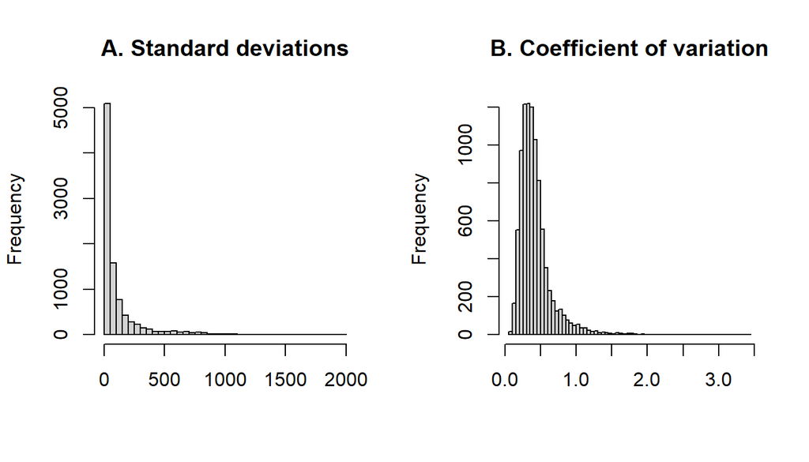

The histogram of standard deviations (A) and coefficient of variation (B).

Is experimental noise independent of absolute magnitude of measurement? **NO**

Accroding to above difination, the coefficient of variation can be calculated with the equation:

$$c_{v}=\sqrt{\frac{1}{n-1}\sum_{i=1}^{n}(\frac{x_{i}}{\overline{x}}-1)^2}$$

That is to say, the dispersion of obtaining value depends on the ration of measurement value and *mean* value, which illustrates that the noise is relevant to the absolute measurement value. 500 samples have been randomly chosen to show the relationship among *mean, variance* and *CV*. It is obvious to see, with the increase of *mean* and *variance* value, the *CV* value performs a dropping trend. figure 2.

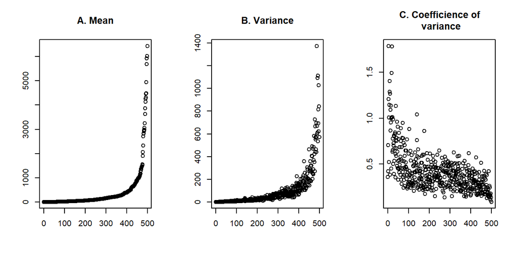

The relationship among mean (A), variance (B), and CV (C). With the increases of the former two values, CV has an obvious dropping trend.

Get the “cleaned” gene subset

Remove all genes except the 1000 with the greatest variation. This will be your “cleaned” data set.

```r
# Getting the rank of variantion
var_dc <- The_variance[order(The_variance,decreasing = T)]
# Keep the top 1000 ranked genes
df_sub <- df[rownames(df) %in% names(var_dc[1:1000]),]
```

##### 3. Normalize

There is a build-in function *scale()* in R able to perform the normalization that each row has zero mean and unit variance.

```r
df_sub_norm <- t(scale(t(df_sub)))
```

##### 4. Perform SVD

There is a build-in function *svd()* in R able to perform the SVD. I used the defualt setting to perform the SVD analysis. The reustls contain:

- d, a vector containing the singular values of matrix, sorted decreasingly;
- u, a matrix whose columns contain the left singular vectors of matrix;
- v, a matrix whose columns contain the right singular vectors of matrix.

Following lines are the *head(3)* of each content.

```r
SVD <- svd(df_sub_norm,nv = 10)

sapply(SVD, function(x) head(x,3))
```

```
  $d
  [1] 118.48558  81.92593  66.60082

  $u
              [,1]         [,2]        [,3]        [,4]         [,5]        [,6]
  [1,] -0.04304027 -0.006353485 -0.01459583 -0.01541453 -0.011282744  0.01131837
  [2,] -0.03748085 -0.023539489 -0.02700427 -0.04119835  0.003341666  0.02497109
  [3,] -0.04123084  0.017659101  0.01939728  0.01299182 -0.004927565 -0.02059720
              [,7]         [,8]         [,9]        [,10]        [,11]
  [1,]  0.02275632 -0.040647626  0.020592277 -0.006490895  0.004995996
  [2,] -0.02653252 -0.006999099 -0.008561893  0.010851076  0.017850165
  [3,] -0.02265388 -0.028211474  0.032580841  0.007620668 -0.030752967
             [,12]       [,13]       [,14]        [,15]       [,16]         [,17]
  [1,]  0.01060743  0.02969657  0.04672217  0.014327581 -0.03974401 -0.0110648579
  [2,]  0.01239896  0.02668866 -0.01542638  0.004736708 -0.04615467  0.0172002619
  [3,] -0.07844366 -0.03844251  0.02015508 -0.003874003  0.03056308  0.0004951917
              [,18]       [,19]       [,20]        [,21]         [,22]
  [1,]  0.081637173 0.009329154 0.029928780  0.066109649 -0.0091305398
  [2,] -0.003113847 0.024178453 0.002324817 -0.003263664  0.0007923078
  [3,]  0.052570731 0.056257857 0.005994210 -0.021009165 -0.0346578803
              [,23]       [,24]        [,25]        [,26]       [,27]       [,28]
  [1,]  0.005250766  0.10724004  0.013996044  0.034119440  0.02681534  0.03492123
  [2,] -0.012068090  0.06174799 -0.022041801 -0.036290296  0.01025699 -0.02763194
  [3,]  0.016043173 -0.01157329  0.006672203 -0.002815855 -0.01984480 -0.01403178
              [,29]        [,30]       [,31]      [,32]
  [1,]  0.008846419  0.032576505  0.02557300  0.3358399
  [2,] -0.032234499  0.016739597 -0.02004410 -0.1223772
  [3,]  0.021952472 -0.008327656  0.02247292 -0.2397787

  $v
            [,1]        [,2]        [,3]        [,4]        [,5]       [,6]
  [1,] 0.2883994 -0.02005807  0.03129863 -0.29707914  0.10258256 -0.2543174
  [2,] 0.3211742 -0.09510665 -0.07786879 -0.21673446  0.06165098  0.3090448
  [3,] 0.1441622  0.09087043 -0.36695699 -0.03115421 -0.30636478  0.3602698
              [,7]        [,8]        [,9]       [,10]
  [1,]  0.36461293 -0.02555757  0.03918776 -0.01504841
  [2,] -0.04862079  0.01539450 -0.16146637  0.28220363
  [3,] -0.05738003  0.06841796  0.14776190  0.37323728
```

Plot the dispersion of the singular values (figure 3).

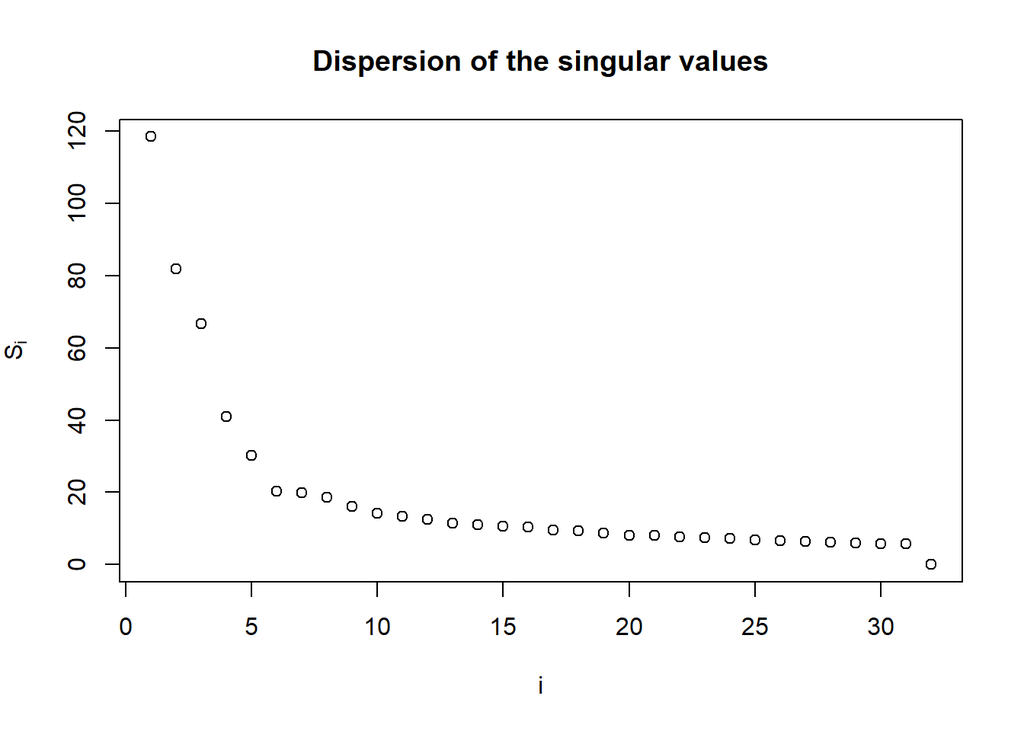

The dispersion of singular values

The eigenvalues of the covariance matrix are related to the squares of the singular values (figure 4A & 4B). R has a build-in function *prcomp()* to performs a principal components analysis on the given data matrix and returns the results as an object of class. From the analysis results below, from the forth component we can get 80% of the variance, see the the cumulative variance plot (figure 4C).

```r
wdbc.pr <- prcomp(df_sub_norm)

cumpro <- cumsum(wdbc.pr$sdev^2 / sum(wdbc.pr$sdev^2))
which(cumpro > 0.8)
```

```
##  [1]  4  5  6  7  8  9 10 11 12 13 14 15 16 17 18 19 20 21 22 23 24 25 26 27 28
## [26] 29 30 31 32
```

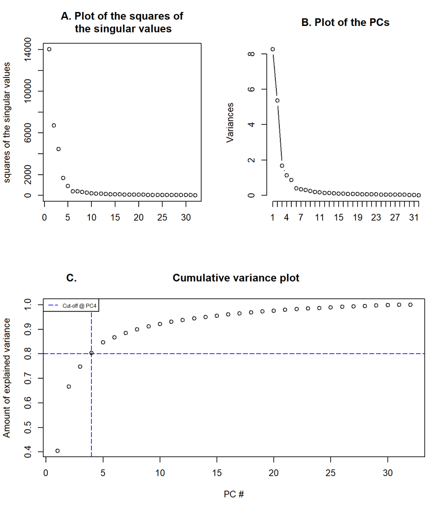

The plot of the squares of the singular values (A), the plot eigenvalues of the covariance matix (B), and the cumulative variance plot(C)

Project the data onto the first 3 principal components.(figure 5)

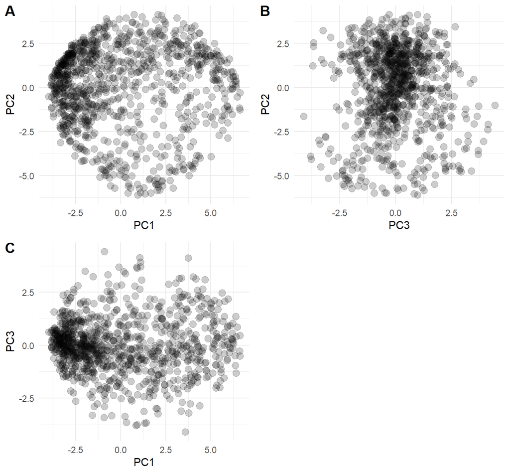

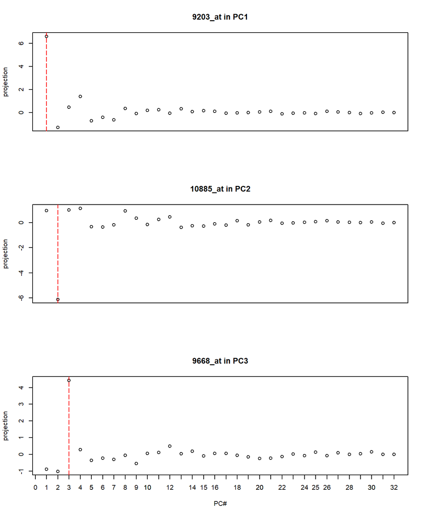

The genes with highest projection in the first three principal component